# Lab_8

Yana Chakalo

October 27, 2017

Using your own dataset (which may include more than one table) carry out the following data cleaning steps. Knit together the PDF document and commit both the Lab 8 RMD file and the PDF document to Git. Push the changes to GitHub so both documents are visible in your public GitHub repository.

**Before you begin: as many of you have large datasets, you’re going to want to select only the variables you’re interested in utilizing for this project (ideally no more than twenty columns but perhaps much smaller) so you don’t have R Studio’s memory working on the entire dataset. The example code provided below can be modified to allow you to subset your data to only the variables you wish to use. First, read in your complete dataset and save it as** `data`. **Then, add the names of the variables you wish to use for your poster project to the** `select` **function, separated by commas. Run the two lines of code to save this new, smaller version of your data to** `data_subset`. **Use this smaller dataset to complete the rest of the lab**

## Installing packages that i might need to use.

```r
options(repos = c(CRAN = "http://cran.rstudio.com"))
#install.packages("dplyr")
#install.packages("packrat")
#install.packages("readr")
#install.packages("foreign")
#install.packages("haven")
#install.packages("knitr")
#install.packages("tidyverse")
library("tidyverse")
library("dplyr")
library("packrat")
library("readr")
library("foreign")
library("haven")
library("knitr")
```

```r
setwd("/Users/soniachakalo/Downloads/Final.Porject.Labs")

opts_knit$set(root.dir = "/Users/soniachakalo/Downloads/Final.Porject.Labs")
getwd()
```

```
## [1] "/Users/soniachakalo/Downloads/Final.Porject.Labs"
```

## Downloading my data set and which variables i want to this lab and to Rstudio.

# Read in your data with the appropriate function

# replace with variable’s you wish to add

```r
data2 <- read_tsv("/Users/soniachakalo/Downloads/Final.Porject.Labs/23625_0002_Data.tsv")
data_subset2 <- data2 %>%
  select(CITY, STATECOD, POP1, TNUMVTMS, TNUMOFF, GOFFRAC, BIASMO1, VTYP_I1, LOCCOD1, VTYP_I1, LOCCOD1)
```

```r
# Read in your data with the appropriate function
data13 <- read_tsv("/Users/soniachakalo/Downloads/Final.Porject.Labs/36118-0002-Data.tsv")
data_subset13 <- data13 %>%
  select(CITY, STATECOD, POP1, TNUMVTMS, TNUMOFF, GOFFRAC, BIASMO1, VTYP_I1, LOCCOD1, VTYP_I1, LOCCOD1)
# replace with variable's you wish to add
```

1. To get a feel for its structure, look at the class, dimensions, column names, structure, and basic summary statistics of your data.
2. Preview the first and last 15 rows of your data. Is you dataset tidy? If not, what principles of tidy data does it seem to be violating?

My data is very tidy. I limited as many varaibles as possible so my data would be easy and get straight to the point in terms of what i want to study. One thing i should look at is where to place the column variables in terms of the best sycnchronization almost like reading a book. For example, I should but state code then city name first in order to see where these crimes were committed. And then the Number of offenders, number of victims per offense and then what the bias is and so on.

## Making my two datasets for 2002 and 2013 into the first 15 and last 15 rows.

```r
tail(data_subset2, 15)
```

```
## # A tibble: 15 x 9
##                CITY STATECOD  POP1 TNUMVTMS TNUMOFF GOFFRAC BIASMO1
##               <chr>    <chr> <int>    <int>   <int>   <chr>   <int>
##  1      MOUNDSVILLE       WV  9962        0       1       U      11
##  2        PRINCETON       WV  6324        0       1       B      11
##  3        PRINCETON       WV  6324        0       1       U      12
##  4        PRINCETON       WV  6324        0       1       U      12
##  5       MORGANTOWN       WV 48797        0       1       W      21
##  6         KINGWOOD       WV 23075        0       0       U      12
##  7         KINGWOOD       WV 23075        0       1       W      12
##  8 NEW MARTINSVILLE       WV  5963        0       1       W      33
##  9        ELIZABETH       WV     0        0       3       W      12
## 10         RAINELLE       WV     0        0       1       W      41
## 11         GILLETTE       WY 14192        1       1       W      32
## 12         GILLETTE       WY 19842        1       2       W      12
## 13          DOUGLAS       WY  4578        2       3       W      12
## 14         CHEYENNE       WY 53539        1       0       U      21
## 15         CHEYENNE       WY 53539        1       0       U      21
## # ... with 2 more variables: VTYP_I1 <int>, LOCCOD1 <int>
```

```r
tail(data_subset13, 15)
```

```
## # A tibble: 15 x 9
##           CITY STATECOD  POP1 TNUMVTMS TNUMOFF GOFFRAC BIASMO1 VTYP_I1
##          <chr>    <chr> <int>    <int>   <int>   <chr>   <int>   <int>
##  1  CHARLESTON       WV 50919        1       2       B      11       1
##  2  CHARLESTON       WV 50919        2       2       W      15       1
##  3  CHARLESTON       WV 50919        1       0       U      21       1
##  4      DUNBAR       WV  7834        2       1       W      42       1
##  5       WELCH       WV 14943        1       3       W      12       1
##  6    FAIRMONT       WV 18740        0       1       W      11       0
##  7    FAIRMONT       WV 18740        3       1       W      23       1
##  8 MOUNDSVILLE       WV  9130        0       1       W      11       0
##  9  MORGANTOWN       WV 31406        1       2       M      32       1
## 10     BECKLEY       WV 17593        1       0       U      11       1
## 11     BECKLEY       WV 17593        1       1       B      11       1
## 12     BECKLEY       WV 17593        1       1       W      12       1
## 13     BECKLEY       WV 17593        1       1       W      41       1
## 14  BUCKHANNON       WV  5649        0       1       W      11       0
## 15    GILLETTE       WY 31884        1       1       W      32       1
## # ... with 1 more variables: LOCCOD1 <int>
```

```r
head(data_subset2, 15)
```

```
## # A tibble: 15 x 9
##          CITY STATECOD   POP1 TNUMVTMS TNUMOFF GOFFRAC BIASMO1 VTYP_I1
##         <chr>    <chr>  <int>    <int>   <int>   <chr>   <int>   <int>
##  1  ANCHORAGE       AK 267280        1       2       U      41       1
##  2  ANCHORAGE       AK 267280        1       1       W      41       1
##  3  ANCHORAGE       AK 267280        1       2       W      12       1
##  4  ANCHORAGE       AK 267280        1       0       U      13       1
##  5  ANCHORAGE       AK 267280        1       4       W      41       1
##  6  ANCHORAGE       AK 267280        1       2       W      13       1
##  7  ANCHORAGE       AK 267280        1       1       W      12       1
##  8   PRICHARD       AL  28886        1       1       B      11       1
##  9 MONTGOMERY       AL  22135        1       5       W      12       1
## 10      EAGAR       AZ   4290        1       0       U      51       1
## 11     BISBEE       AZ   6476        1       2       W      41       1
## 12  FLAGSTAFF       AZ      0        1       1       W      42       1
## 13      GLOBE       AZ  18962        1       0       U      33       1
## 14      GLOBE       AZ  18962        0       2       W      11       0
## 15      GLOBE       AZ  18962        2       1       W      32       1
## # ... with 1 more variables: LOCCOD1 <int>
```

```r
head(data_subset13, 15)
```

```
## # A tibble: 15 x 9
##           CITY STATECOD   POP1 TNUMVTMS TNUMOFF GOFFRAC BIASMO1 VTYP_I1
##          <chr>    <chr>  <int>    <int>   <int>   <chr>   <int>   <int>
##  1   ANCHORAGE       AK 299455        1       1       U      12       1
##  2   ANCHORAGE       AK 299455        2       1       W      13       1
##  3   ANCHORAGE       AK 299455        1       4       W      12       1
##  4   ANCHORAGE       AK 299455        1       1       W      12       1
##  5   ANCHORAGE       AK 299455        1       1       W      12       1
##  6   ANCHORAGE       AK 299455        1       0       U      12       1
##  7   ANCHORAGE       AK 299455        1       1       W      13       1
##  8   ANCHORAGE       AK 299455        1       1       W      13       1
##  9      HOOVER       AL  60284        1       2       M      41       1
## 10  PRATTVILLE       AL  33293        1       1       W      12       1
## 11  PRATTVILLE       AL  33293        1       1       W      12       1
## 12    FLORENCE       AL  39481        1       1       U      12       1
## 13    FLORENCE       AL  39481        1       1       U      15       1
## 14  TUSCALOOSA       AL  94126        1       1       W      12       1
## 15 BENTONVILLE       AR  39132        1       1       W      12       1
## # ... with 1 more variables: LOCCOD1 <int>
```

3. Create a histogram for at least two variables you plan to focus on for your study. Describe what these plots show you about these variables.

## Histogram of the 2002 data of bias motives

[figure not shown]

```r
hist(data_subset2$BIASMO1,
     main = "Histogram for motive bias of the offense",
     xlab = "VTYP_I1",
     ylab = "BIASMO1",
     border = "blue",
     col = "blue")
```

## Histogram of 2013 data of Bias motives

[figure not shown]

```r
hist(data_subset13$BIASMO1,
     main = "Histogram for motive bias of the offense",
     xlab = "VTYP_I1",
     ylab = "BIASMO1",
     border = "blue",
     col = "blue")
```

4. Create at least one bivariate plot showing the relationship between two variables of interest. What does/do the(se) plot(s) tell you about the association between these two variables?

## Making a bivariate scatterplot for my two data sets.

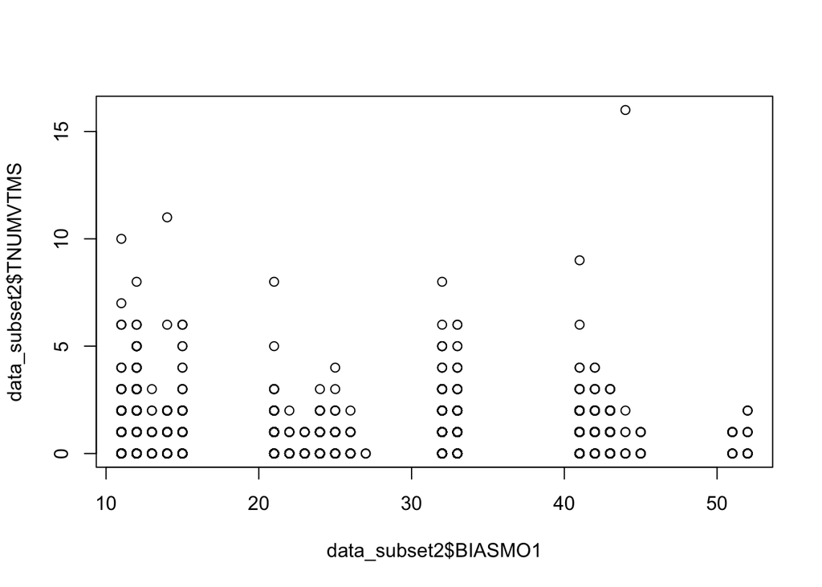

```r
plot(data_subset2$BIASMO1, data_subset2$TNUMVTMS)
```

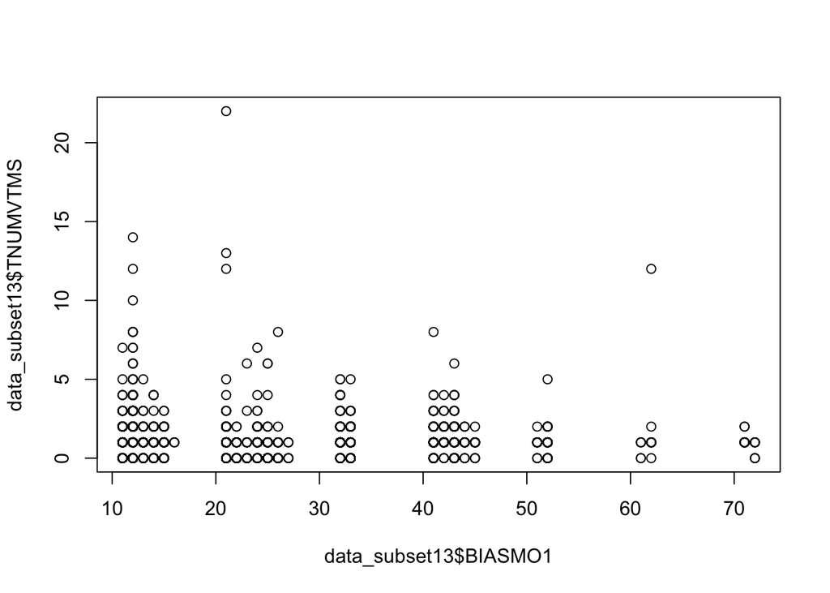

```r
plot(data_subset13$BIASMO1, data_subset13$TNUMVTMS)
```

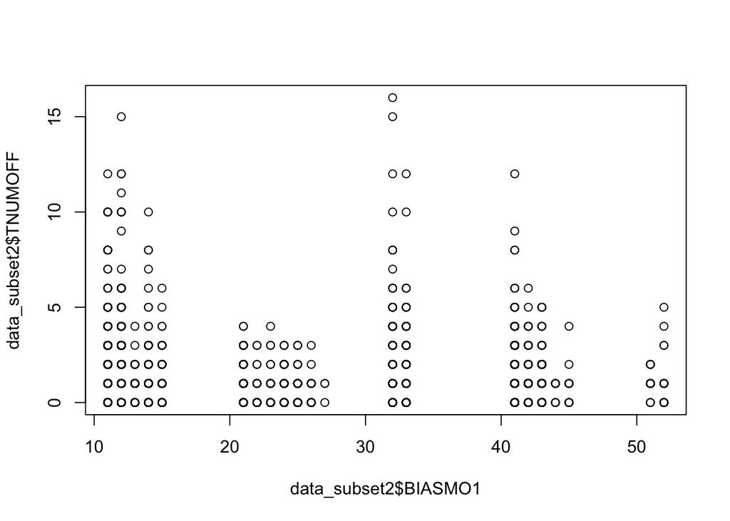

```r
plot(data_subset2$BIASMO1, data_subset2$TNUMOFF)
```

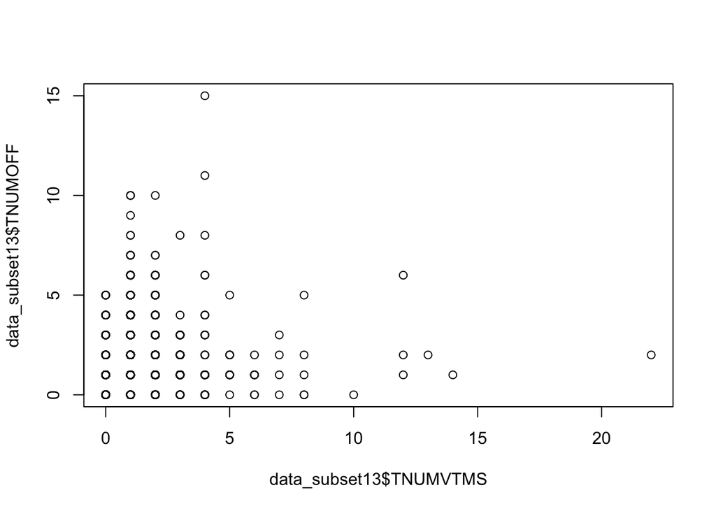

```r
plot(data_subset13$TNUMVTMS, data_subset13$TNUMOFF)
```

5. Load the `tidyr` package. Do all of your columns correspond to variables? Do any columns represent multiple variables? If your answer is yes to either question, carry out the appropriate `tidyr` function (`gather()` or `spread()` respectively) to tidy your data.

## Installed tidyr package

```r
install.packages("tidyr")
```

All of my columns in my data do represent variables. So i am using the gather function on the 2002 and 2013 data sets.

```r
gathered.data_subset2 <- gather(data_subset2, -CITY, -STATECOD, -POP1, -TNUMVTMS, -TNUMOFF, -GOFFRAC, -BIASMO1, -VTYP_I1, -LOCCOD1, -VTYP_I1, -LOCCOD1)
head(gathered.data_subset2, 15)
```

```
## # A tibble: 15 x 9
##      POP1 TNUMVTMS TNUMOFF GOFFRAC BIASMO1 VTYP_I1 LOCCOD1 `-CITY`
##     <int>    <int>   <int>   <chr>   <int>   <int>   <int>   <chr>
##  1 267280        1       2       U      41       1      13    CITY
##  2 267280        1       1       W      41       1       7    CITY
##  3 267280        1       2       W      12       1      13    CITY
##  4 267280        1       0       U      13       1      25    CITY
##  5 267280        1       4       W      41       1       1    CITY
##  6 267280        1       2       W      13       1      13    CITY
##  7 267280        1       1       W      12       1      20    CITY
##  8  28886        1       1       B      11       1       3    CITY
##  9  22135        1       5       W      12       1      13    CITY
## 10   4290        1       0       U      51       1      13    CITY
## 11   6476        1       2       W      41       1      13    CITY
## 12      0        1       1       W      42       1      20    CITY
## 13  18962        1       0       U      33       1      14    CITY
## 14  18962        0       2       W      11       0      21    CITY
## 15  18962        2       1       W      32       1      20    CITY
## # ... with 1 more variables: `-STATECOD` <chr>
```

```r
gathered.data_subset13 <- gather(data_subset13, -CITY, -STATECOD, -POP1, -TNUMVTMS, -TNUMOFF, -GOFFRAC, -BIASMO1, -VTYP_I1, -LOCCOD1, -VTYP_I1, -LOCCOD1)
head(gathered.data_subset13, 15)
```

```
## # A tibble: 15 x 9
##      POP1 TNUMVTMS TNUMOFF GOFFRAC BIASMO1 VTYP_I1 LOCCOD1 `-CITY`
##     <int>    <int>   <int>   <chr>   <int>   <int>   <int>   <chr>
##  1 299455        1       1       U      12       1      13    CITY
##  2 299455        2       1       W      13       1      13    CITY
##  3 299455        1       4       W      12       1      20    CITY
##  4 299455        1       1       W      12       1      13    CITY
##  5 299455        1       1       W      12       1      13    CITY
##  6 299455        1       0       U      12       1      20    CITY
##  7 299455        1       1       W      13       1      13    CITY
##  8 299455        1       1       W      13       1      13    CITY
##  9  60284        1       2       M      41       1      21    CITY
## 10  33293        1       1       W      12       1      18    CITY
## 11  33293        1       1       W      12       1      22    CITY
## 12  39481        1       1       U      12       1      21    CITY
## 13  39481        1       1       U      15       1       8    CITY
## 14  94126        1       1       W      12       1      20    CITY
## 15  39132        1       1       W      12       1      25    CITY
## # ... with 1 more variables: `-STATECOD` <chr>
```

6. Do any columns need to be separated into two or more? Do any columns need to be combined into one? If so, carry out the appropriate the appropriate `tidyr` function (`separate()` or `unite()` respectively) to tidy your data.

None of my data needs this.

**At this stage each row in your data should represent one observation, each column should be a variable, and each table should be observational unit.**

7. What is the class of each of the variables in your analysis? Are these classes appropriate for the type of measurement they purport to capture? Explain your reasoning.

My variables classs for my data set is categories and numericals ranges pertaining to how many victims and offenders there were in the incident. The categorical variables pertain to a numeric associated with a certain type of bias motive, city name, and state. These types of classes do appropriatly resemble the data becasue you cannot rate bias or city or state as better then the other. You do need to have a ordered numeric in order ot know how many victims and offenders there were in the incident.

8. Do any of your variables need to be coerced into a different data type? If so, carry out the appropriate coercion methods below. (This includes transformation of any date objects using the `lubridate` package)

I believe my data type as it is works really well in understanding the information.

9. Are there any strings you need to manipulate for your analysis? If so, use the appropriate function from the [`stringr`](https://cran.r-project.org/web/packages/stringr/vignettes/stringr.html) package.

I believe all of my strings are fine.

10. Do you have any missing values in your dataset? How many and how are they coded? **Be sure to look out for specific codebook values for missing values (i.e. `-1` for `NA`) as well as empty strings or other software-specific values for `NA`.** Don’t worry about removing NAs yet - we’ll tackle this question later once discern whether they’re random or systematically distributed.

11. Are there any special values in your dataset? If so, what are they and how do you think they got there? *The presence of special values is less likely if you haven’t performed any data manipulation yet so you should remember to return to this step each time you carry out a mathematical transformation of any values in your dataset.*

I do have some special values for example the values indicating the race of the offender which is indicated by a first letter that is associated with the race word itself. For example white race would be indicated as W and black would use B and asian A.

12. Create a boxplot of your data (you can create an individual boxplot for each variable if there are too many variables in your dataset to meaningfully visualize them all in one plot). Are there any outliers? If so, what are they and to which variable do they correspond? Do any of these outliers seem like obvious errors? If so, why?

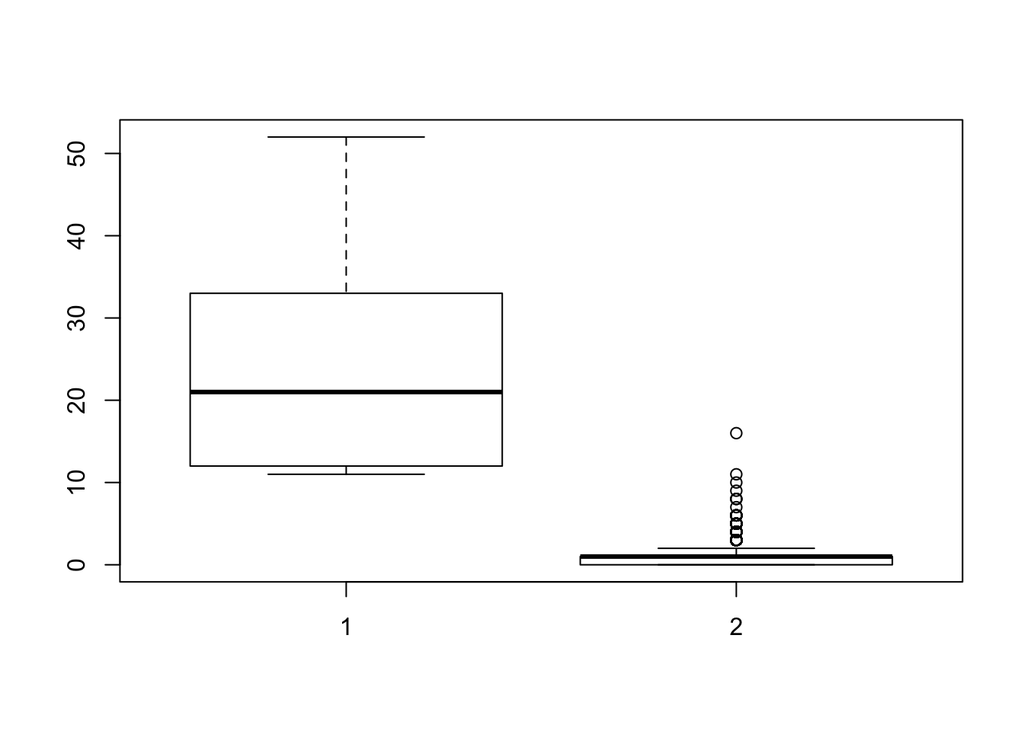

```r
boxplot(data_subset2$BIASMO1, data_subset2$TNUMVTMS)
```

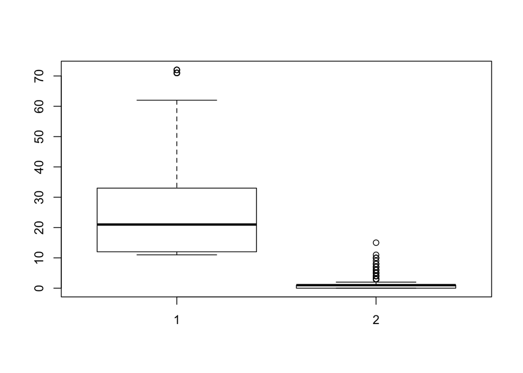

```r
boxplot(data_subset13$BIASMO1, data_subset13$TNUMOFF)
```

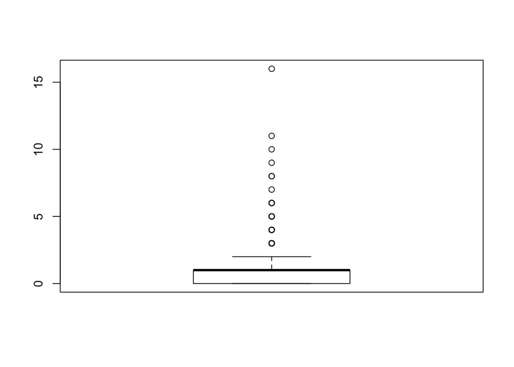

```r
boxplot(data_subset2$TNUMVTMS)
```

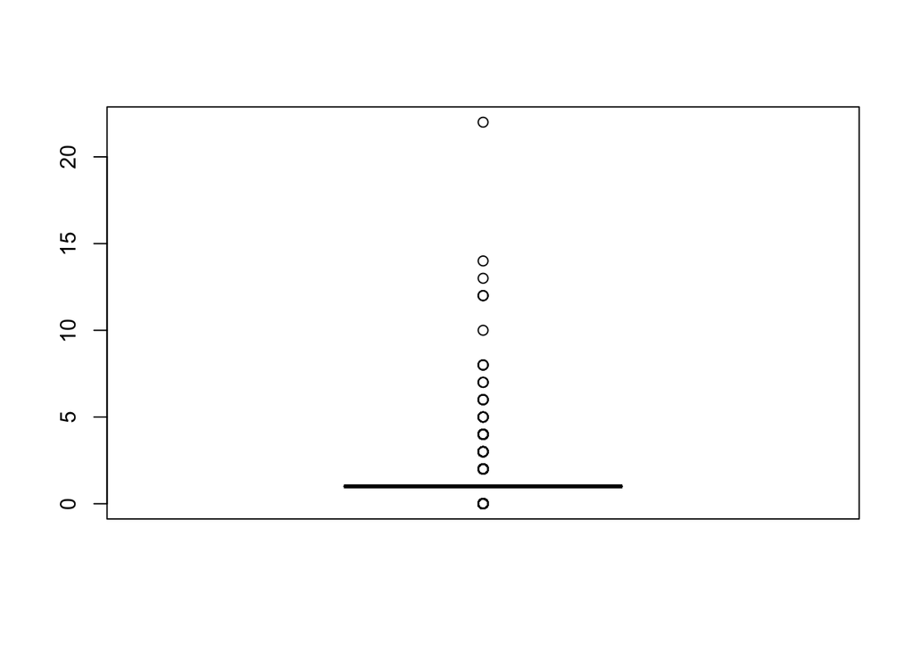

```r
boxplot(data_subset13$TNUMVTMS)
```

13. For any outliers and/or obvious errors, what do you think is the best way to handle them (i.e. remove them entirely, run analyses including and excluding them and compare the results, manually change them to an appropriate measure of center, or something else?).

The best way to handle my data in regards to outliers would be to take them out and see how it affects my data as well as change them to the appropriate measure of center.